# Homework 6

Han Siyue 17307110012

2019/11/23

### Packages for Bootstrap

```r
library(boot)
library(bootstrap)
```

### Exercise 7.3

Obtain a bootstrap t confidence interval estimate for the correlation statistic in Example 7.2 (`law` data in `bootstrap`).

```r
boot.t.ci <- function(x, B = 500, R = 100, level = .95, statistic){
  #compute the bootstrap t CI
  x <- as.matrix(x);  n <- nrow(x)
  stat <- numeric(B); se <- numeric(B)

  boot.se <- function(x, R, f) {
    #local function to compute the bootstrap
    #estimate of standard error for statistic f(x)
    x <- as.matrix(x); m <- nrow(x)
    th <- replicate(R, expr = {
      i <- sample(1:m, size = m, replace = TRUE)
      f(x[i, ])
    })
    return(sd(th))
  }

  for (b in 1:B) {
    j <- sample(1:n, size = n, replace = TRUE)
    y <- x[j, ]
    stat[b] <- statistic(y)
    se[b] <- boot.se(y, R = R, f = statistic)
  }
  stat0 <- statistic(x)
  t.stats <- (stat - stat0) / se
  se0 <- sd(stat)
  alpha <- 1 - level
  Qt <- quantile(t.stats, c(alpha/2, 1-alpha/2), na.rm = T, type = 1)
  names(Qt) <- rev(names(Qt))
  CI <- rev(stat0 - Qt * se0)
}

data(law, package = "bootstrap")
dat <- cbind(law$LSAT, law$GPA)
stat1 <- function(dat) {
  cor(dat[, 1], dat[, 2])
}
ci <- boot.t.ci(dat, statistic = stat1, B=2000, R=200)
print(ci)
```

```
##       2.5%      97.5%
## -0.3212916  0.9724364
```

### Exercise 7.4

Refer to the air-conditioning data set `aircondit` provided in the `boot` package. The 12 observations are the times in hours between failures of airconditioning equipment [63, Example 1.1]: 3, 5, 7, 18, 43, 85, 91, 98, 100, 130, 230, 487. Assume that the times between failures follow an exponential model Exp($\lambda$). Obtain the MLE of the hazard rate $\lambda$ and use bootstrap to estimate the bias and standard error of the estimate.

```r
data(aircondit, package = "boot")

# MLE for lambda
lambda.MLE <- function(x){
  L <- function(lambda, x){
    sum(log(lambda) - lambda * x)
  }
  lambda.MLE <- optimize(L, interval = c(0, 10), maximum = TRUE, x = x)
  lambda.MLE$maximum
}

lambda.hat <- lambda.MLE(aircondit$hours)

# bootstrap estimate of bias
B <- 2000
n <- nrow(aircondit)
lambda.b <- numeric(B)

for (b in 1:B) {
  i <- sample(1:n, size = n, replace = TRUE)
  x.boot <- aircondit$hours[i]
  lambda.b[b] <- lambda.MLE(x.boot)
}

bias <- mean(lambda.b) - lambda.hat
bias
```

```
## [1] 0.001253024
```

```r
# bootstrap estimate of standard error
se <- sd(lambda.b)
se
```

```
## [1] 0.004043192
```

### Exercise 7.6

Efron and Tibshirani discuss the `scor` (`bootstrap`) test score data on 88 students who took examinations in five subjects [84, Table 7.1], [188, Table 1.2.1]. The first two tests (mechanics, vectors) were closed book and the last three tests (algebra, analysis, statistics) were open book. Each row of the data frame is a set of scores $(x_{i1}, \cdots, x_{i5})$ for the $i^{th}$ student. Use a panel display to display the scatter plots for each pair of test scores.

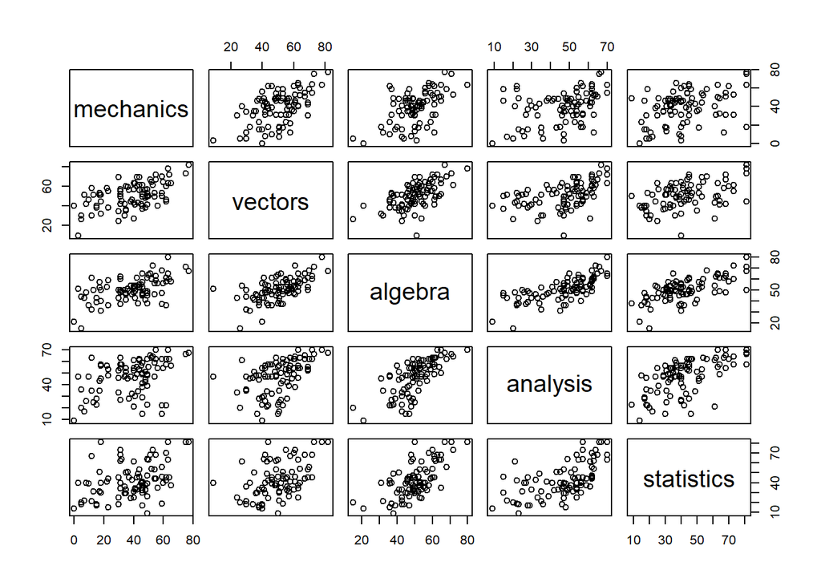

```r
data(scor, package = "bootstrap")
pairs(scor, c("mechanics", "vectors", "algebra", "analysis", "statistics"))
```

Compare the plot with the sample correlation matrix.

```r
data <- scor
names(data) <- c("mechanics", "vectors", "algebra", "analysis", "statistics")
corr_mat <- cor(data, data)
corr_mat
```

```
##            mechanics   vectors   algebra  analysis statistics
## mechanics  1.0000000 0.5534052 0.5467511 0.4093920  0.3890993
## vectors    0.5534052 1.0000000 0.6096447 0.4850813  0.4364487
## algebra    0.5467511 0.6096447 1.0000000 0.7108059  0.6647357
## analysis   0.4093920 0.4850813 0.7108059 1.0000000  0.6071743
## statistics 0.3890993 0.4364487 0.6647357 0.6071743  1.0000000
```

Obtain bootstrap estimates of the standard errors for each of the following estimates: $\hat\rho_{12}$ = $\hat\rho$(mec, vec), $\hat\rho_{34}$ = $\hat\rho$(alg, ana), $\hat\rho_{35}$ = $\hat\rho$(alg, sta), $\hat\rho_{45}$ = $\hat\rho$(ana, sta).

```r
## set up the bootstrap
B <- 2000           #number of replicates
n <- nrow(data)     #sample size

## build a function for bootstrap estimate of standard error
boot_est <- function(x1, x2){
  rho <- numeric(B)
  for (b in 1:B) {
    # randomly select the indice
    i <- sample(1:n, size = n, replace = TRUE)
    # select dataframe according to the indice and change it to vector
    x1.sample <- as.vector(as.matrix(data[i, x1]))
    x2.sample <- as.vector(as.matrix(data[i, x2]))
    rho[b] <- cor(x1.sample, x2.sample)
  }
  se <- sd(rho)
  return(se)
}

## calculate the result and print the result
R12 <- boot_est(1, 2)
R34 <- boot_est(3, 4)
R35 <- boot_est(3, 5)
R45 <- boot_est(4, 5)
result <- data.frame(R = c(R12, R34, R35, R45), row.names = c("ρ(mec, vec)","ρ(alg, ana)","ρ(alg, sta)","ρ(ana, sta)"))
names(result) <- "standard errors"
result
```

```
##             standard errors
## ρ(mec, vec)      0.07561502
## ρ(alg, ana)      0.04915041
## ρ(alg, sta)      0.06070961
## ρ(ana, sta)      0.06737569
```

### Exercise 7.7

Refer to Exercise 7.6. Efron and Tibshirani discuss the following example [84, Ch. 7]. The five-dimensional scores data have a $5 \times 5$ covariance matrix $\Sigma$, with positive eigenvalues $\lambda_1 > \cdots > \lambda_5$. In principal components analysis,
$$\theta = \frac{\lambda_1}{\sum_{j=1}^5 \lambda_j}$$
measures the proportion of variance explained by the first principal component. Let $\hat\lambda_1 > \cdots > \hat\lambda_5$ be the eigenvalues of $\hat\Sigma$, where $\hat\Sigma$ is the MLE of $\Sigma$. Compute the sample estimate
$$\hat\theta = \frac{\hat\lambda_1}{\sum_{j=1}^5 \hat\lambda_j}$$
of $\theta$. Use bootstrap to estimate the bias and standard error of $\hat\theta$.

```r
data.cov <- cov(data, data)
data.lambda <- eigen(data.cov)$values
data.theta <- data.lambda[1] / sum(data.lambda)

## the bootstrap
B <- 2000           #number of replicates
n <- nrow(data)     #sample size
sample.theta <- numeric(B)
for (b in 1:B) {
  # randomly select the indice
  i <- sample(1:n, size = n, replace = TRUE)
  sample <- data[i, ]
  sample.cov <- cov(sample, sample)
  sample.lambda <- eigen(sample.cov)$values
  sample.theta[b] <- sample.lambda[1] / sum(sample.lambda)
}
bias <- mean(sample.theta) - data.theta
se <- sd(sample.theta)
print(cbind(bias, se))
```

```
##             bias         se
## [1,] 0.002015502 0.04822778
```

### Proj 6.D

Repeat Example 6.11 for multivariate tests of normality. Mardia [187] defines multivariate kurtosis as
$$\beta_{2,d}=E[(X-\mu)^T\Sigma^{-1}(X-\mu)]^2$$
For $d$-dimensional multivariate normal distributions the kurtosis coefficient is $\beta_{2,d} = d(d + 2)$. The multivariate kurtosis statistic is
$$b_{2,d}=\frac1n \sum_{i=1}^n((X_i-\bar X)^T\widehat\Sigma^{-1}(X_i-\bar X)) \tag{6.6}$$
The large sample test of multivariate normality based on $b_{2,d}$ rejects the null hypothesis at significance level $\alpha$ if
$$\left|\frac{b_{2,d}-d(d + 2)}{\sqrt{8d(d + 2)/n}}\right| \ge \Phi^{-1}(1-\alpha/2)$$
However, $b_{2,d}$ converges very slowly to the normal limiting distribution. Compare the empirical power of Mardia’s skewness and kurtosis tests of multivariate normality with the energy test of multivariate normality `mvnorm.etest`(`energy`) (6.3) [226, 263]. Consider multivariate normal location mixture alternatives where the two samples are generated from `mlbench.twonorm` in the `mlbench` package [174].

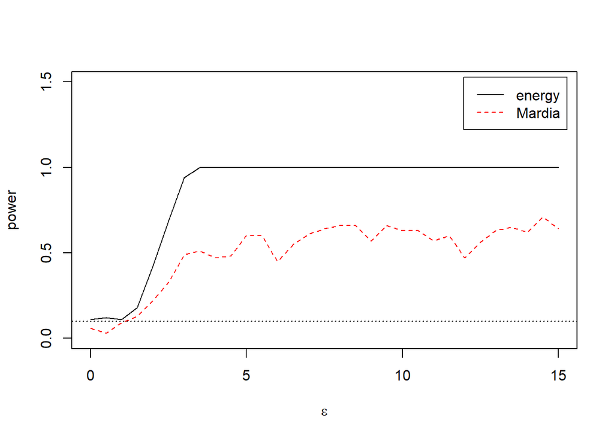

```r
library(energy)
library(mlbench)

alpha <- .1
d <- 2
n <- 30
m <- 100        #try small m for a trial run
epsilon <- c(seq(0, 1, .1))
test1 <- test2 <- test3 <- test4 <- numeric(m)
cv.mardia <- qnorm(1-alpha/2, 0, 1)
sim <- matrix(0, 31, 3)

mardia <- function(x,d){
  #computes Mardia test
  x.mean <- colMeans(x)
  signa.inverse <- solve(cov(x))
  result <- 0
  for (i in 1:n){
    result <- result + (t(x[i, ]-x.mean) %*% signa.inverse  %*% (x[i, ]-x.mean))^2
  }
  beta <- result / n
  mardia.test <- abs((beta - d*(d+2))/sqrt(8*d*(d+2)/n))
  return(mardia.test)
}

# estimate power
for (i in 0:30) {
  epsilon <- i * .5
  for (j in 1:m) {
    p <- mlbench.2dnormals(n, d, epsilon)
    x <- p[["x"]]
    test1[j] <- as.integer(mvnorm.etest(x, R=200)$p.value <= alpha)
    test2[j] <- as.integer(abs(mardia(x,d)) >= cv.mardia)
  }
  sim[i+1, ] <- c(epsilon, mean(test1), mean(test2))
}

# plot the empirical estimates of power
plot(sim[,1], sim[,2], ylim = c(0, 1.5), type = "l",
     xlab = bquote(epsilon), ylab = "power")
lines(sim[,1], sim[,3], lty = 2, col = 2)
abline(h = alpha, lty = 3)
legend("topright", 1, c("energy", "Mardia"),
       lty = c(1,2), col = c(1,2), inset = .02)
```